# scRNAseq data analysis (EBs 7g): Doublets identification

Researcher: Luis García Palma

Author: María Maqueda

13th May 2024

# Scope

This document aims to conduct doublets (or multiplets) detection over scRNAseq data samples and filter them for downstream analysis. Doublet (multiplet) detection aims to remove multiple cells captured within the same droplet (heterotypic).

# Primary data

A total of **six samples** were library-prepared and sequenced by NovoGene Co, Ltd. Libraries were prepared using **10x Single Cell 3’v3 kit**. Corresponding biological samples were delivered to IJC at the end of October’23 and sequencing data was received at the end of February’24. Samples are equally divided in two conditions, considering cells from **mouse embryoid bodies (mEBs 144h)** :

- in wild-type (**WT**) condition (3x) and,
- after activation of 7* specific genes (**7g**) (3x) identified by CRISPRa in an earlier project phase.

*Genes related to HSC development fate.

# Methods

Doublets(/multiplets) were identified by means of `scDblFinder` R package (Germain et al. 2022) (v1.14.0). This tool aims to identify heterotypic doublets (doublets formed from different cell types or states). Input data should not contain empty droplets in place. Filtered matrices (`filtered_feature_bc_matrix`) obtained from CellRanger are used. Random and cluster-based approaches are used (implemented in the same package)*. Additionally, cluster-based approach is also used with the clusters identified by CellRanger software (graph-based approach). Those cells labelled as doublets by two out of the three approaches will be removed from the dataset during the following QC process. Doublets are separately for each sample. For more information about this package, check https://github.com/plger/scDblFinder.

# Results

NOTE: The determining factor for doublet formation is the number of cells inserted to the machine, it could also be that less cells than expected are recovered.

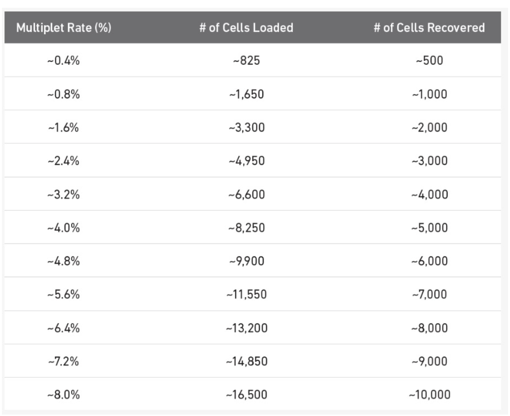

Samples are classified as singlets or doublets as indicated in the table below. **Doublets percentage ranges between 8.2% and 10.5%** which is roughly the expected quantity (slightly higher for sample `WT_s2`)

## Comparison between random and cluster-based approaches

Following tables show the number of doublets classified per sample when applying the random or cluster-based approach.

- Random-based approach

RANDOM-BASED FROM scDblFinder. Number of classifed cells into singlets or doublets. Doublets percentage calculated over the total number of cells per sample

|  | Singlets | Doublets | Doublets_Percentage |
| --- | --- | --- | --- |
| WT_s1 | 7091 | 666 | 8.6% |
| WT_s2 | 6459 | 755 | 10.5% |
| WT_s3 | 7947 | 764 | 8.8% |
| g7_s1 | 7996 | 789 | 9% |
| g7_s2 | 6974 | 627 | 8.2% |
| g7_s3 | 6422 | 687 | 9.7% |

- Cluster-based approach (implementation in `scDblFinder`)

CLUSTERS-BASED FROM scDblFinder. Number of classifed cells into singlets or doublets. Doublets percentage calculated over the total number of cells per sample

|  | Singlets | Doublets | Doublets_Percentage |
| --- | --- | --- | --- |
| WT_s1 | 7209 | 548 | 7.1% |
| WT_s2 | 6512 | 702 | 9.7% |
| WT_s3 | 7972 | 739 | 8.5% |
| g7_s1 | 7843 | 942 | 10.7% |
| g7_s2 | 6950 | 651 | 8.6% |
| g7_s3 | 6516 | 593 | 8.3% |

- Cluster-based approach (results from `CellRanger`)

CLUSTERS-BASED FROM CELL RANGER. Number of classifed cells into singlets or doublets. Doublets percentage calculated over the total number of cells per sample

|  | Singlets | Doublets | Doublets_Percentage |
| --- | --- | --- | --- |
| WT_s1 | 7114 | 643 | 8.3% |
| WT_s2 | 6420 | 794 | 11% |
| WT_s3 | 7924 | 787 | 9% |
| g7_s1 | 8055 | 730 | 8.3% |
| g7_s2 | 6931 | 670 | 8.8% |
| g7_s3 | 6523 | 586 | 8.2% |

Similar results are obtained. Cluster-based approaches are recommended for those datasets with a very clear structure whereas the random approach for more complex ones. For this dataset, it is expected to have a clear structure.

The overlapping in doublets labelling between both cases is:

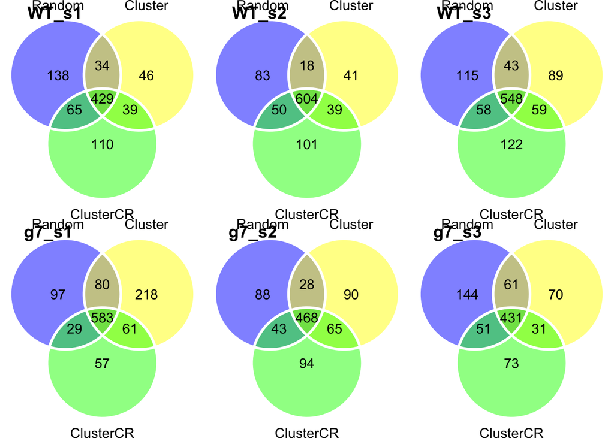

Overlap of doublets identification

Most of detected doublets are shared among the three methods. Let’s combine results and proceed with the final labelling for removal (a cell is defined as a doublet if it has been detected as such in two out of the three methods).

# CONCLUSION

Cells have been classified into singlets or doublets following three different approaches: (i) without considering any clustering information and considering cells clustering based on (ii) fast two-step clustering already (implemented in `scDblFinder` package) consisting of k-means + louvain clustering (graph-based) and (iii) graph-based clustering (implemented in `Cell Ranger` software) consisting of a graph-based (louvain) clustering (operating in the PCA space).

Different results are obtained from the three different approaches, **as a final conclusion: a cell is labelled as doublet if it has been classified as such by at least two out the three approaches**. Per sample, it means:

- **g7_s1**: 753 out of the initial 8785 cells (8.6 %).
- **g7_s2**: 604 out of the initial 7601 cells (7.9 %).
- **g7_s3**: 574 out of the initial 7109 cells (8.1 %).
- **WT_s1**: 567 out of the initial 7757 cells (7.3 %).
- **WT_s2**: 711 out of the initial 7214 cells (9.9 %).
- **WT_s3**: 708 out of the initial 8711 cells (8.1 %).

**These cells are removed from the dataset during the QC process.**

# References

Germain, Pierre-Luc, Aaron Lun, Carlos Garcia Meixide, and Will Macnair. 2022. “Doublet identification in single-cell sequencing data using scDblFinder [version 2; peer review: 2 approved].” *F1000Research* 10: 979.